# Indicators Analysis

Victoria Zaitceva

2024-12-17

gvv,bsp and b2 - type 2 - Региональные сосудистые центры b15 - type 1 - Первичное сосудистое отделение, там не все индикаторы качества выполняются, поэтому я бы его исключила и вообще сравнивала РСЦ и ПСО отдельно

```r
group1 <- c("gvv","bsp","b2")
all_data_group1 <- database_summarized_month %>% filter(hosp %in% group1)
```

# Структура заболеваемости

## Возраст - Общегородская динамика возрастной структуры пациентов (все центры)

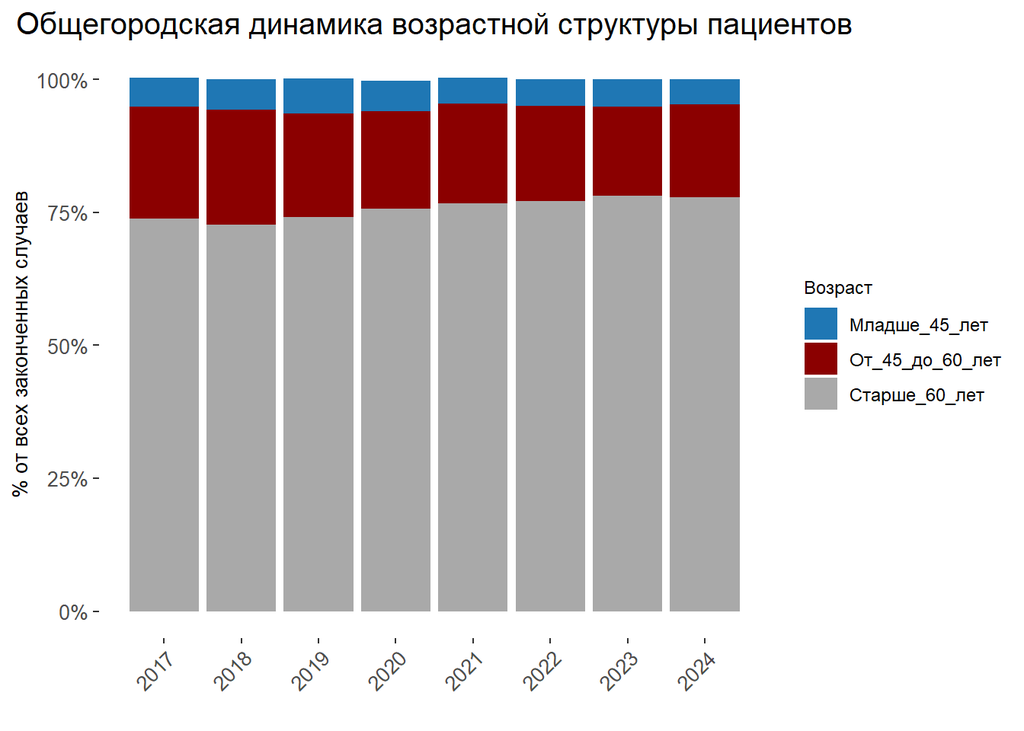

## NIHSS - Общий городской уровень тяжести по NIHSS (все центры)

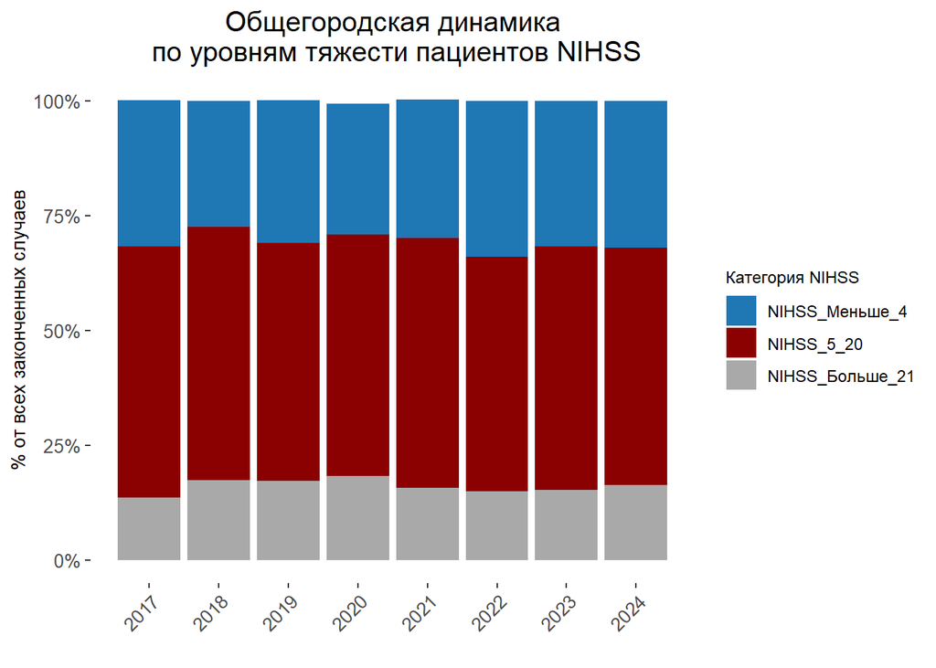

## Динамика в структуре заболевания (%) по годам общегородская, line plot

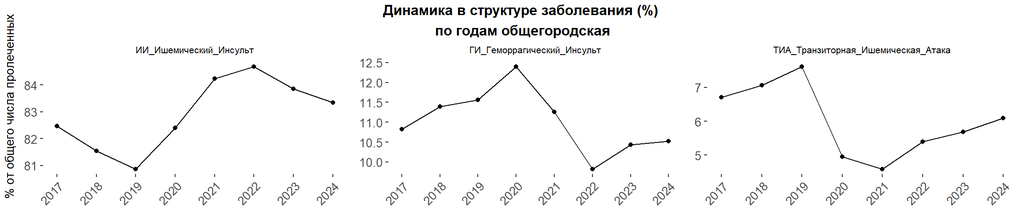

## Динамика в структуре заболевания (%) общегородская - по месяцам, line plot

Сделала линию тренда, чтобы просто показать как линия выглядит если делать по месяца, но предлагаю для любых показателей по месяцам точки получше выглядят.

Линии только для годовой динамики.

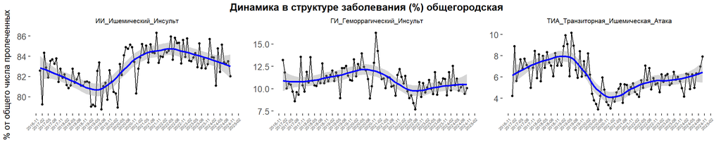

## Динамика структуры заболеваемости по месяцам в группе 1 (% от общего числа пролеченных)

То же самое, что и сверху, but scatter plot

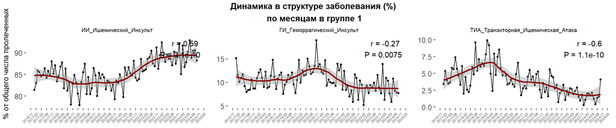

# ИИ процедуры (тромболизис и др)

## Годовая доля тромболизиса от общего числа ИИ случаев - line plot

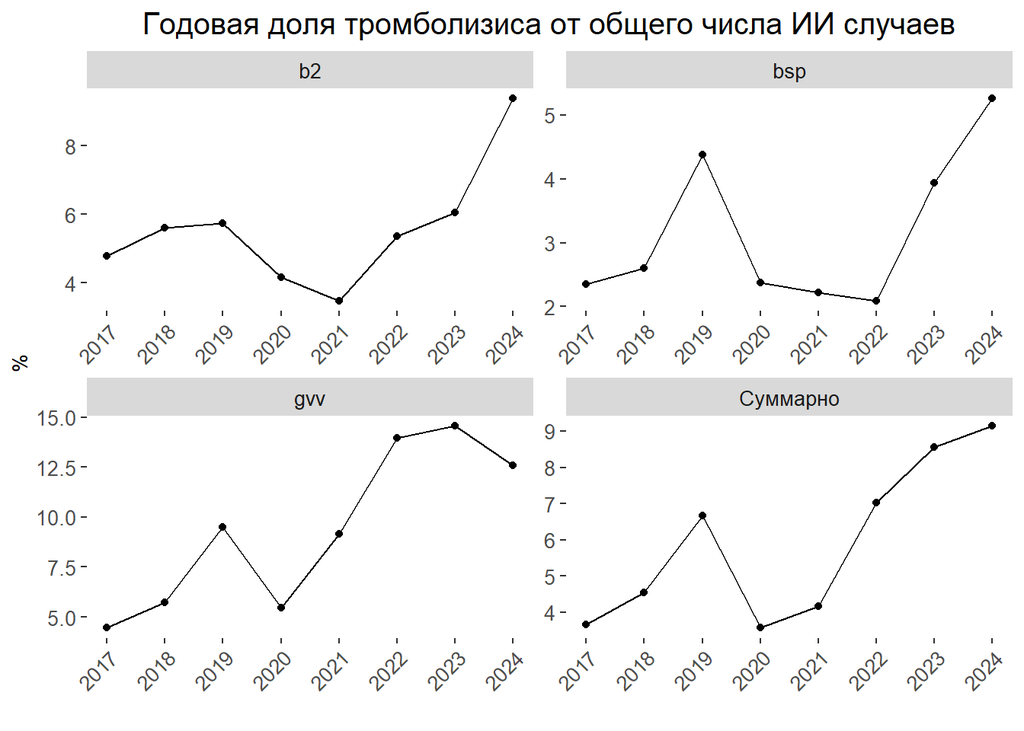

## Процедуры при ИИ по годам в группе 1 , РСЦ

% от общего числа ИИ

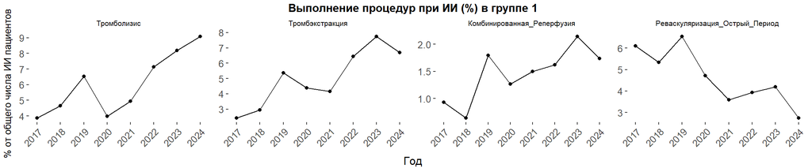

## Процедуры при ИИ по месяцам в группе 1 , РСЦ

% от общего числа ИИ

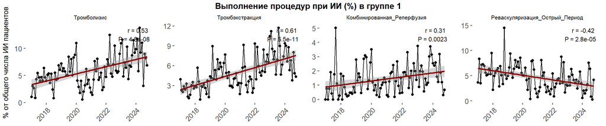

Каждая процедура зависит от тяжести по NIHSS, возможно надо считать каждую процедуру как % от числа пациентов с определенным NIHSS, а не от общего числа ИИ пациентов.

Типы процедур при ИИ явно не суммируются в 100%, поэтому что-то отсутсвует в данных

Может быть посмотреть как соотношение уровней тяжести для каждого типа процедур меняется во времени Один центр - один график, где по оси Х - год, а по оси Y - барплоты с разными процетными соотношениями уровней тяжести.

Процедура - барплоты, разделенные по уровням тяжести

# Категории NIHSS для процедур при ИИ

Может быть для каждой категории NIHSS характерна своя процедура?

Для проекта наверно неинформативно, просто решила посмотреть.

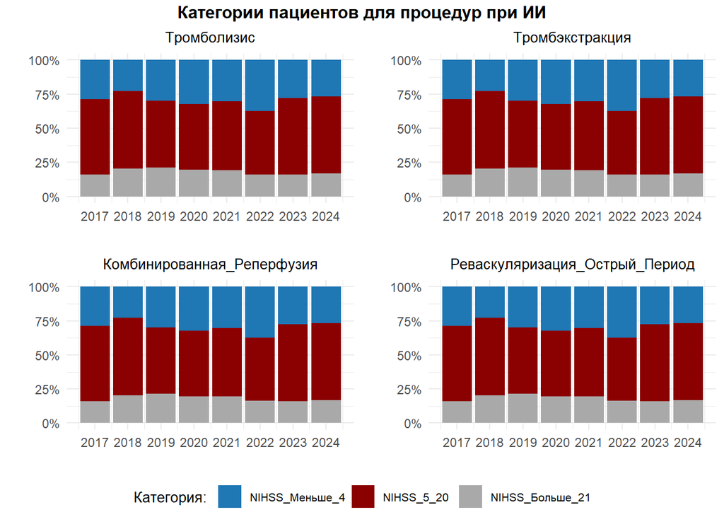

Процентные соотношения аналогичны общегородским в целом.

# Летальные исходы

## Общегородская доля летальных исходов от общего числа пролеченных случаев

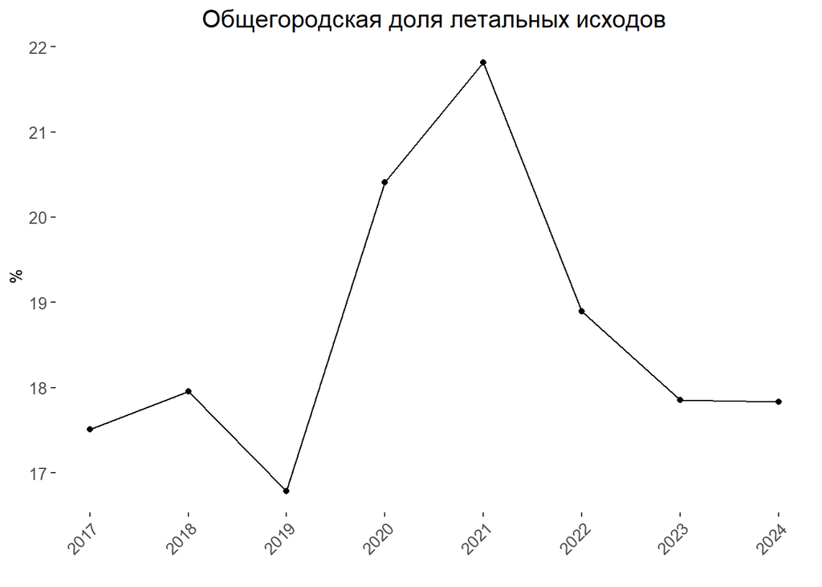

## Годовая доля летальных исходов в группе 1

% от Пролечены_с_ОНМК_Всего

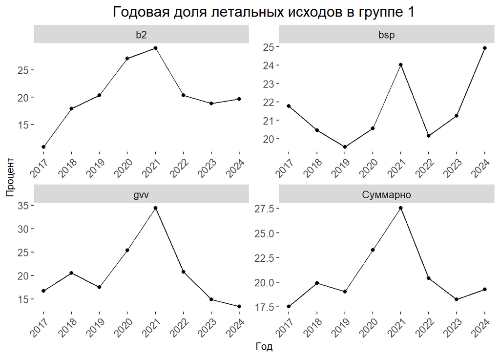

(Не могу сделать Годовая доля летальных исходов в зависимости от типа инсульта в группе 1 , потому что это неизвестно)

## Динамика летальных исходов по месяцам в группе 1 - line plot

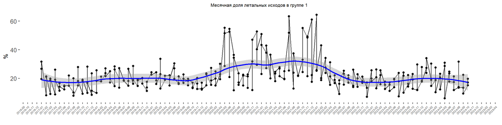

## Летальные исходы в сутки - ?

Это среднее число за неделю?

# Терапевтическое окно

## Годовые общегородские доли пациентов, попавших в ТО (4.5 часа)

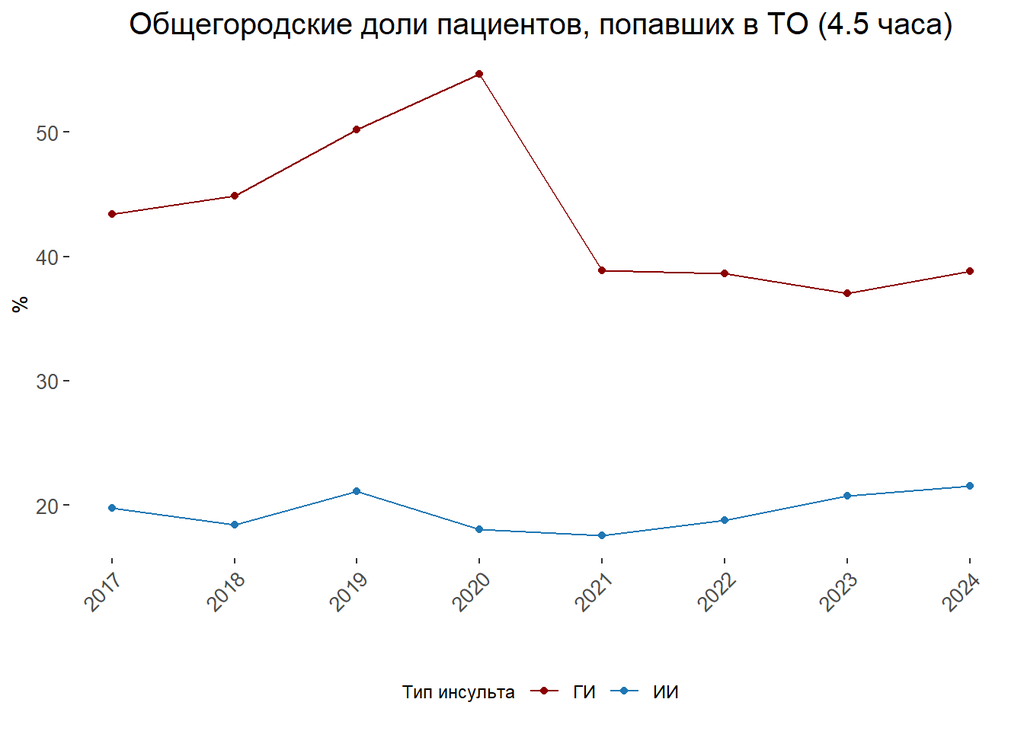

## Годовые доли пациентов, попавших в ТО (4.5 часа) в группе 1

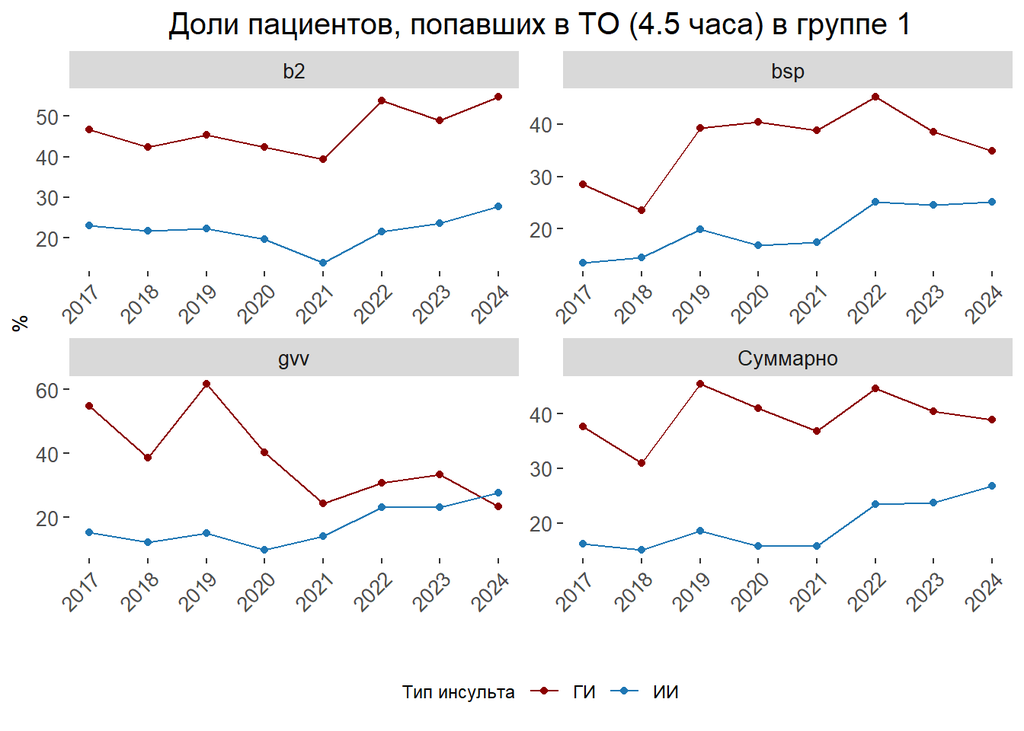

## Динамика пациентов, попавших в ТО (4.5 часа) по месяцам в группе 1

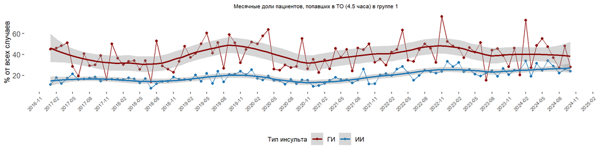

# Выписка

## Выписано / Госпализировано (%) - общегородской monthly trend line

% от суммы Госпитализированы_с_ОНМК + Внутрибольничные_ОНМК

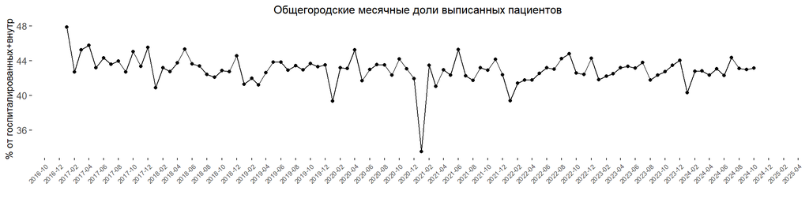

## Выписано / Госпализировано (%) - monthly trend line для каждого РСЦ в группе 1

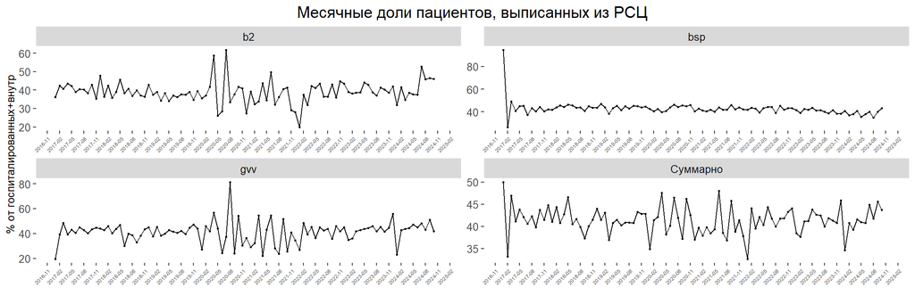

# Корреляционный анализ между изменениями в летальных исходах и индикаторами

## Correlation matrix

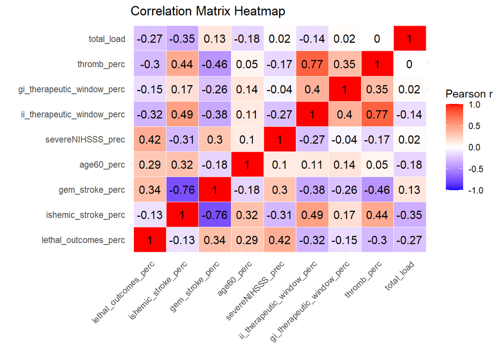

## Lagged Correlation Between Scaled Hospital Load and Mortality Rate

Суммарная_Загрузка_ОНМК / 10

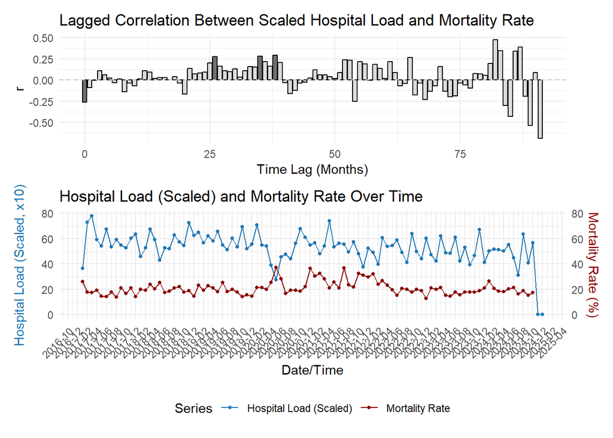

```
##  [1] "hosp"                               "type"
##  [3] "year"                               "month"
##  [5] "Всего_с_ОНМК"                       "Не_подтвержден_ОНМК"
##  [7] "Госпитализированы_с_ОНМК"           "Пролечены_с_ОНМК_Всего"
##  [9] "Внутрибольничные_ОНМК"              "ИИ_Ишемический_Инсульт"
## [11] "ТИА_Транзиторная_Ишемическая_Атака" "ГИ_Геморрагический_Инсульт"
## [13] "ВМК_ВЖК"                            "САК_Неподтвержденная_Аневризма"
## [15] "Кровоизлияние_АВМ"                  "САК_Аневризма"
## [17] "Терапевтическое_Окно_4_5ч"          "ИИ_Терапевтическое_Окно"
## [19] "ГИ_Терапевтическое_Окно"            "Переведены_ПСО_РСЦ"
## [21] "ГИ_Переведены_до_48ч"               "ИИ_Переведены_до_12ч"
## [23] "ИИ_Переведены_до_2_недель"          "Направлены_на_Реабилитацию"
## [25] "II_Этап_Реабилитация"               "III_Этап_Реабилитация"
## [27] "Паллиативное_Лечение"               "Сестринский_Уход"
## [29] "Амбулаторное_Лечение"               "Собственная_Реабилитация_II_Этап"
## [31] "Младше_45_лет"                      "От_45_до_60_лет"
## [33] "Старше_60_лет"                      "NIHSS_Меньше_4"
## [35] "NIHSS_Больше_21"                    "NIHSS_5_20"
## [37] "Тромболизис"                        "Тромбэкстракция"
## [39] "Комбинированная_Реперфузия"         "Реваскуляризация_Острый_Период"
## [41] "ГИ_Всего"                           "Летальные_Исходы"
## [43] "Летальные_Исходы_1_Сутки"           "Выписаны_Всего"
## [45] "Ривермид_1_Балл"                    "Ривермид_2_4_Балла"
## [47] "Ривермид_5_8_Баллов"                "Ривермид_9_Баллов"
## [49] "Суммарная_Загрузка_ОНМК"            "Суммарно_Госпитализировано"
```

Еще сделай барплоты по шкале ривермид в соотношении c выписаны всего

“Выписаны_Всего”  
[45] “Ривермид_1_Балл” “Ривермид_2_4_Балла”  
[47] “Ривермид_5_8_Баллов” “Ривермид_9_Баллов”

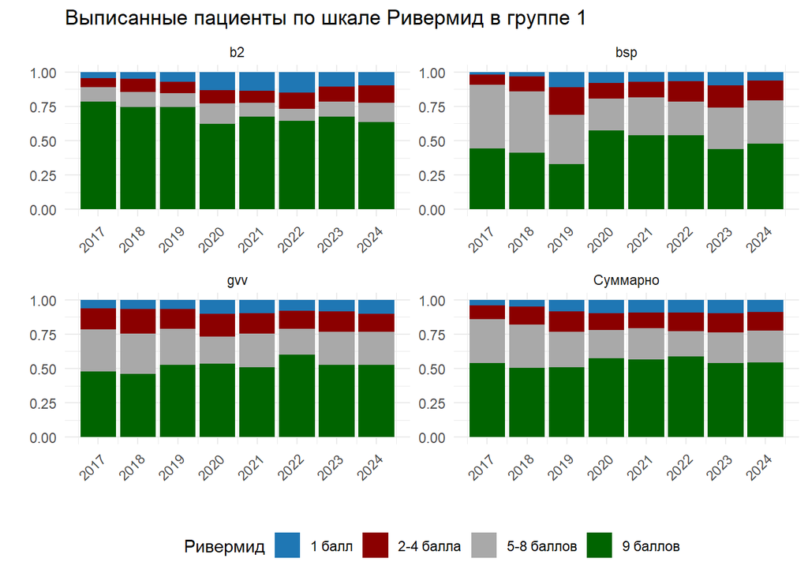

```
## [1] "English_United Kingdom.utf8"
```